# Section 2 Data Cleaning & Visualization

———————————————-#  
Set Up the Environment  
Set the working directory

```r
library(data.table)
library(dplyr)
```

```r
library(ggplot2)
library(tidyr)
library(corrplot)
library(caTools)
library(lubridate)
library(rpart)
library(rpart.plot)
PATH <- "/Users/ss5390/Downloads/"
```

### Section 2: Data Cleaning & Data Visualization

import the ‘kkbox train’ final dataset we created in Section 1

```r
kkbox_train <- fread(paste0(PATH,"kkbox train.csv"))
```

```
##
Read 63.2% of 869896 rows
Read 869896 rows and 22 (of 22) columns from 0.113 GB file in 00:00:04
```

```r
str(kkbox_train)
```

```
## Classes 'data.table' and 'data.frame':   869896 obs. of  22 variables:
##  $ msno                  : chr  "yxiEWwE9VR5utpUecLxVdQ5B7NysUPfrNtGINaM2zA8=" "PNxIsSLWOJDCm7pNPFzRO/6Mmg2WeZA2nf6hw6t1x3g=" "KXF9c/T66LZIzFq+xS64icWMhDQE6miCZAtdXRjZHX8=" "OcZ3fKQzHrL1BuzuFRzUiwPr8l9P8JKCFpafdYf5sCY=" ...
##  $ <25%                  : int  3069 110 627 1677 10704 2315 3234 1096 2308 2170 ...
##  $ 25%-50%               : int  921 83 161 449 1390 664 635 174 507 218 ...
##  $ 50%-75%               : int  702 50 95 356 1091 472 338 120 373 142 ...
##  $ 75%-98.5%             : int  562 62 87 823 1138 395 248 234 384 128 ...
##  $ 98.5%-100%            : int  32237 1870 1829 14884 14597 6668 9260 5441 13817 4335 ...
##  $ num_unq               : int  24788 1725 2335 13466 22627 7394 10061 5916 13389 6052 ...
##  $ total_secs            : num  8465161 483809 479448 4079853 4008327 ...
##  $ number_days_of_use    : int  653 116 195 625 581 344 506 167 537 133 ...
##  $ total_list_price      : int  2086 2235 3874 2533 2384 2384 2682 1790 2831 894 ...
##  $ total_amount_paid     : int  2980 3129 3874 2682 3278 3278 2831 1790 2980 894 ...
##  $ total_auto_renew      : int  20 21 26 18 22 22 19 10 20 4 ...
##  $ total_is_cancel       : int  0 0 0 0 0 0 0 0 1 0 ...
##  $ num_of_transactions   : int  20 21 26 18 22 22 19 13 20 6 ...
##  $ average_amount_paid   : num  149 149 149 149 149 ...
##  $ city                  : int  13 13 5 6 4 22 13 4 13 5 ...
##  $ bd                    : int  32 37 33 30 30 27 30 26 40 37 ...
##  $ gender                : chr  "female" "male" "female" "female" ...
##  $ registered_via        : int  9 9 9 9 9 9 9 9 9 9 ...
##  $ registration_init_time: int  20040327 20040328 20040331 20040404 20040630 20040712 20040717 20040801 20040805 20040806 ...
##  $ expiration_date       : int  20171102 20171001 20170918 20170801 20170930 20170930 20171027 20170922 20170927 20171217 ...
##  $ is_churn              : int  0 0 0 0 0 0 0 0 1 0 ...
##  - attr(*, ".internal.selfref")=<externalptr>
```

#### Variables Reclassification, Organization and Preparation

converting ‘registration_init_time’ and ‘expiration_date’ into date format

```r
kkbox_train$registration_init_time = ymd(kkbox_train$registration_init_time)
kkbox_train$expiration_date = ymd(kkbox_train$expiration_date)
```

changing some variables into factors and checking their levels

```r
kkbox_train[,c("msno","city","gender","registered_via")] = lapply(kkbox_train[,c("msno","city","gender","registered_via")],factor)
str(kkbox_train)
```

```
## Classes 'data.table' and 'data.frame':   869896 obs. of  22 variables:
##  $ msno                  : Factor w/ 869896 levels "///2pAPKetZe8zPqAwkYBjAUr+4pS8Rc6bsO4eGAlWI=",..: 840723 588006 460307 551568 268118 746694 600740 337846 155692 405470 ...
##  $ <25%                  : int  3069 110 627 1677 10704 2315 3234 1096 2308 2170 ...
##  $ 25%-50%               : int  921 83 161 449 1390 664 635 174 507 218 ...
##  $ 50%-75%               : int  702 50 95 356 1091 472 338 120 373 142 ...
##  $ 75%-98.5%             : int  562 62 87 823 1138 395 248 234 384 128 ...
##  $ 98.5%-100%            : int  32237 1870 1829 14884 14597 6668 9260 5441 13817 4335 ...
##  $ num_unq               : int  24788 1725 2335 13466 22627 7394 10061 5916 13389 6052 ...
##  $ total_secs            : num  8465161 483809 479448 4079853 4008327 ...
##  $ number_days_of_use    : int  653 116 195 625 581 344 506 167 537 133 ...
##  $ total_list_price      : int  2086 2235 3874 2533 2384 2384 2682 1790 2831 894 ...
##  $ total_amount_paid     : int  2980 3129 3874 2682 3278 3278 2831 1790 2980 894 ...
##  $ total_auto_renew      : int  20 21 26 18 22 22 19 10 20 4 ...
##  $ total_is_cancel       : int  0 0 0 0 0 0 0 0 1 0 ...
##  $ num_of_transactions   : int  20 21 26 18 22 22 19 13 20 6 ...
##  $ average_amount_paid   : num  149 149 149 149 149 ...
##  $ city                  : Factor w/ 21 levels "1","3","4","5",..: 12 12 4 5 3 21 12 3 12 4 ...
##  $ bd                    : int  32 37 33 30 30 27 30 26 40 37 ...
##  $ gender                : Factor w/ 3 levels "","female","male": 2 3 2 2 3 2 3 2 3 2 ...
##  $ registered_via        : Factor w/ 5 levels "3","4","7","9",..: 4 4 4 4 4 4 4 4 4 4 ...
##  $ registration_init_time: Date, format: "2004-03-27" "2004-03-28" ...
##  $ expiration_date       : Date, format: "2017-11-02" "2017-10-01" ...
##  $ is_churn              : int  0 0 0 0 0 0 0 0 1 0 ...
##  - attr(*, ".internal.selfref")=<externalptr>
```

gender has 3 levels

```r
levels(kkbox_train$gender)
```

```
## [1] ""       "female" "male"
```

We decided to keep the ‘blanks’ factors of gender since we suspect they may impact the churn rate.  
We will label them as “Unknown”

```r
levels(kkbox_train$gender)[levels(kkbox_train$gender)==""] = "unknown"
```

verfying the absense of missing values

```r
sum(is.na(kkbox_train))
```

```
## [1] 0
```

we will create a new variable that indicates the average discount a user received

```r
kkbox_train$avg_discount = (kkbox_train$total_list_price - kkbox_train$total_amount_paid) / kkbox_train$num_of_transactions
```

replace or remove unnessary column ‘total_amount_paid’ and ‘total_list_price’ add new column ‘avg_list_price’ b/c we will be working with only averages

```r
kkbox_train$avg_list_price <- kkbox_train$total_list_price/kkbox_train$num_of_transactions
kkbox_train <- kkbox_train %>% select(-total_amount_paid, -total_list_price)
```

clarifying the ‘average_amount_paid’ variable by changing its name

```r
colnames(kkbox_train)[which(colnames(kkbox_train) == "average_amount_paid")] = "avg_amt_paid_per_tran"
```

```r
str(kkbox_train)
```

```
## Classes 'data.table' and 'data.frame':   869896 obs. of  22 variables:
##  $ msno                  : Factor w/ 869896 levels "///2pAPKetZe8zPqAwkYBjAUr+4pS8Rc6bsO4eGAlWI=",..: 840723 588006 460307 551568 268118 746694 600740 337846 155692 405470 ...
##  $ <25%                  : int  3069 110 627 1677 10704 2315 3234 1096 2308 2170 ...
##  $ 25%-50%               : int  921 83 161 449 1390 664 635 174 507 218 ...
##  $ 50%-75%               : int  702 50 95 356 1091 472 338 120 373 142 ...
##  $ 75%-98.5%             : int  562 62 87 823 1138 395 248 234 384 128 ...
##  $ 98.5%-100%            : int  32237 1870 1829 14884 14597 6668 9260 5441 13817 4335 ...
##  $ num_unq               : int  24788 1725 2335 13466 22627 7394 10061 5916 13389 6052 ...
##  $ total_secs            : num  8465161 483809 479448 4079853 4008327 ...
##  $ number_days_of_use    : int  653 116 195 625 581 344 506 167 537 133 ...
##  $ total_auto_renew      : int  20 21 26 18 22 22 19 10 20 4 ...
##  $ total_is_cancel       : int  0 0 0 0 0 0 0 0 1 0 ...
##  $ num_of_transactions   : int  20 21 26 18 22 22 19 13 20 6 ...
##  $ avg_amt_paid_per_tran : num  149 149 149 149 149 ...
##  $ city                  : Factor w/ 21 levels "1","3","4","5",..: 12 12 4 5 3 21 12 3 12 4 ...
##  $ bd                    : int  32 37 33 30 30 27 30 26 40 37 ...
##  $ gender                : Factor w/ 3 levels "unknown","female",..: 2 3 2 2 3 2 3 2 3 2 ...
##  $ registered_via        : Factor w/ 5 levels "3","4","7","9",..: 4 4 4 4 4 4 4 4 4 4 ...
##  $ registration_init_time: Date, format: "2004-03-27" "2004-03-28" ...
##  $ expiration_date       : Date, format: "2017-11-02" "2017-10-01" ...
##  $ is_churn              : int  0 0 0 0 0 0 0 0 1 0 ...
##  $ avg_discount          : num  -44.7 -42.57 0 -8.28 -40.64 ...
##  $ avg_list_price        : num  104 106 149 141 108 ...
##  - attr(*, ".internal.selfref")=<externalptr>
```

split the ‘kkbox_train’ into ‘train’ and ‘test’ dataset

```r
set.seed(1)
split <- sample.split(kkbox_train$msno,SplitRatio = 0.7)
train <- kkbox_train[split,]
test <- kkbox_train[!split,]
rm(split)
```

#### Data Visualization and Further Preparation for Numeric Variables

```r
train_plot1 <- Filter(is.numeric,train) %>%
  gather (key, value,-is_churn) #gathering all numerics for a more generalized visualization
```

looking how numeric variables affect the predicted value

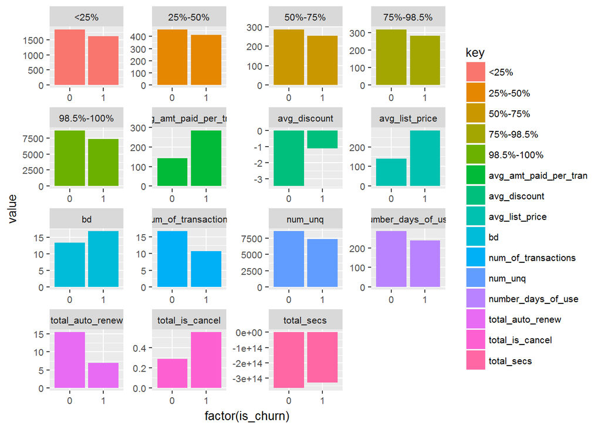

```r
ggplot(train_plot1,aes(x=factor(is_churn),y=value,fill=key))+
  geom_bar(position='dodge',stat='summary',fun.y='mean')+
  facet_wrap(~ key, scales="free")+
  theme(text = element_text(size=10))
```

looking for outliers

```r
summary(train)
```

```
##                                            msno             <25%
##  ///2pAPKetZe8zPqAwkYBjAUr+4pS8Rc6bsO4eGAlWI=:     1   Min.   :     0
##  ///mTKUVQV0oYwb1acUes7piDWa9GLvLDDKru+THzQ0=:     1   1st Qu.:   280
##  //+uXIKe+NMJmGyARqgZzvpVF58WgsDauMtz+1WXOFQ=:     1   Median :   900
##  //0G+KopxUhyRVSoDHtzwjOe8Jv+2T/7cV7Ukz+x9FQ=:     1   Mean   :  1833
##  //1tIUeF70BEHRxcQ5SuArPy7N8GVh4dBCaUutmysAQ=:     1   3rd Qu.:  2290
##  //1vaNpN6xyfTBfsNKR0j1e0Lv8/eRyQjPt+nKU1ehk=:     1   Max.   :132484
##  (Other)                                     :608921
##     25%-50%           50%-75%          75%-98.5%       98.5%-100%
##  Min.   :    0.0   Min.   :    0.0   Min.   :    0   Min.   :     0
##  1st Qu.:   76.0   1st Qu.:   49.0   1st Qu.:   48   1st Qu.:  1226
##  Median :  244.0   Median :  157.0   Median :  161   Median :  4488
##  Mean   :  455.7   Mean   :  285.4   Mean   :  317   Mean   :  8641
##  3rd Qu.:  593.0   3rd Qu.:  378.0   3rd Qu.:  399   3rd Qu.: 11213
##  Max.   :40823.0   Max.   :37596.0   Max.   :56441   Max.   :444898
##
##     num_unq         total_secs         number_days_of_use total_auto_renew
##  Min.   :     1   Min.   :-4.151e+17   Min.   :  1.0      Min.   : 0.00
##  1st Qu.:  1421   1st Qu.: 3.006e+05   1st Qu.: 83.0      1st Qu.: 7.00
##  Median :  4858   Median : 1.144e+06   Median :233.0      Median :16.00
##  Mean   :  8495   Mean   :-3.624e+14   Mean   :282.2      Mean   :14.91
##  3rd Qu.: 11652   3rd Qu.: 2.879e+06   3rd Qu.:453.0      3rd Qu.:23.00
##  Max.   :268047   Max.   : 9.223e+15   Max.   :790.0      Max.   :62.00
##
##  total_is_cancel   num_of_transactions avg_amt_paid_per_tran
##  Min.   : 0.0000   Min.   : 1.00       Min.   :   0.0
##  1st Qu.: 0.0000   1st Qu.: 9.00       1st Qu.:  99.0
##  Median : 0.0000   Median :17.00       Median : 145.0
##  Mean   : 0.3034   Mean   :16.28       Mean   : 152.2
##  3rd Qu.: 0.0000   3rd Qu.:24.00       3rd Qu.: 149.0
##  Max.   :20.0000   Max.   :64.00       Max.   :2000.0
##
##       city              bd              gender       registered_via
##  1      :311028   Min.   :-2828.0   unknown:332652   3 : 73512
##  13     : 69557   1st Qu.:    0.0   female :131222   4 : 34595
##  5      : 49911   Median :    0.0   male   :145053   7 :334296
##  4      : 33960   Mean   :   13.6                    9 :164328
##  15     : 30524   3rd Qu.:   27.0                    13:  2196
##  22     : 29716   Max.   : 2015.0
##  (Other): 84231
##  registration_init_time expiration_date         is_churn
##  Min.   :2004-03-26     Min.   :2011-03-06   Min.   :0.00000
##  1st Qu.:2012-02-10     1st Qu.:2017-09-12   1st Qu.:0.00000
##  Median :2014-05-19     Median :2017-09-23   Median :0.00000
##  Mean   :2013-09-03     Mean   :2017-09-12   Mean   :0.06565
##  3rd Qu.:2016-01-07     3rd Qu.:2017-10-02   3rd Qu.:0.00000
##  Max.   :2017-02-28     Max.   :2025-10-02   Max.   :1.00000
##
##   avg_discount      avg_list_price
##  Min.   :-894.000   Min.   :   0.0
##  1st Qu.:  -5.519   1st Qu.:  99.0
##  Median :   0.000   Median : 138.5
##  Mean   :  -3.299   Mean   : 148.9
##  3rd Qu.:   0.000   3rd Qu.: 149.0
##  Max.   : 149.000   Max.   :2000.0
##
```

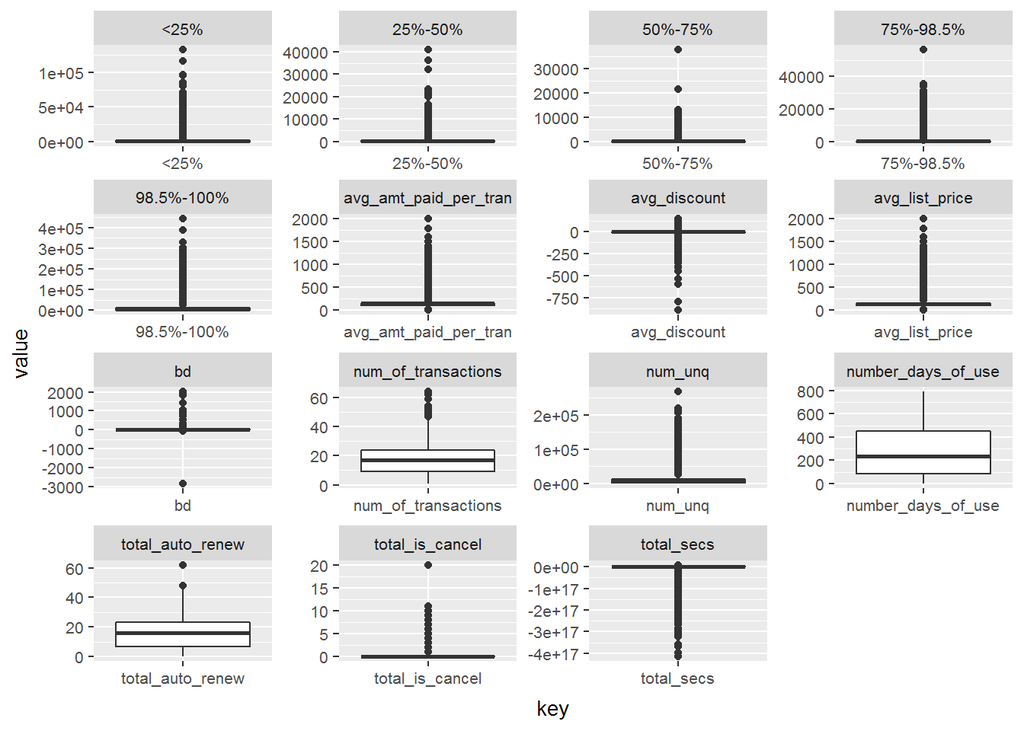

```r
ggplot(train_plot1,aes(x=key,y=value))+
  geom_boxplot()+
  facet_wrap( ~ key, scales="free")+
  theme(text = element_text(size=10))
```

```r
rm(train_plot1)
```

from the boxplot, ‘bd’ contains a lot of negative ages and > 100 ages

```r
length(which(train$bd <=0 | train$bd >= 100)) / nrow(train) #54.8% of all observations are unreasonable
```

```
## [1] 0.5480558
```

checking the potential influence of “reasonable” ages on our predicted value

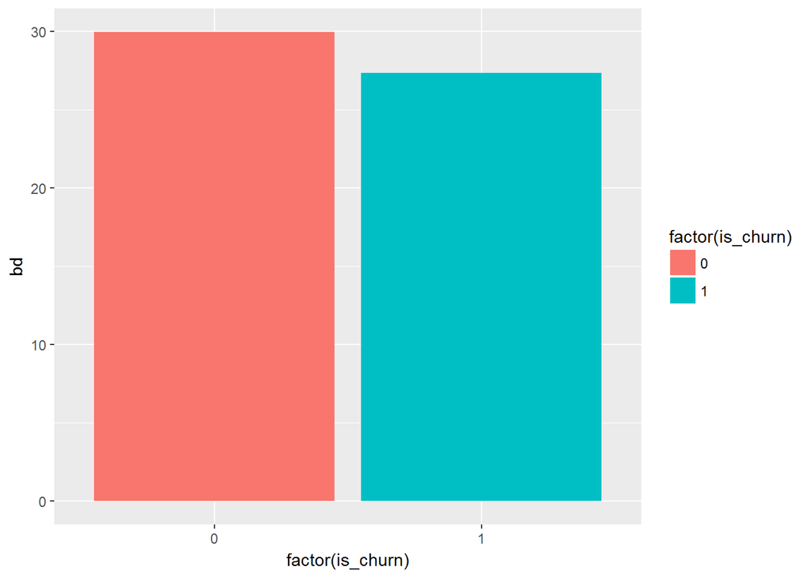

```r
no_outliers <- train[!which(train$bd <=0 | train$bd >= 100),]
ggplot(no_outliers,aes(x=factor(is_churn),y=bd, fill = factor(is_churn)))+
  geom_bar(position='dodge',stat='summary',fun.y='mean')
```

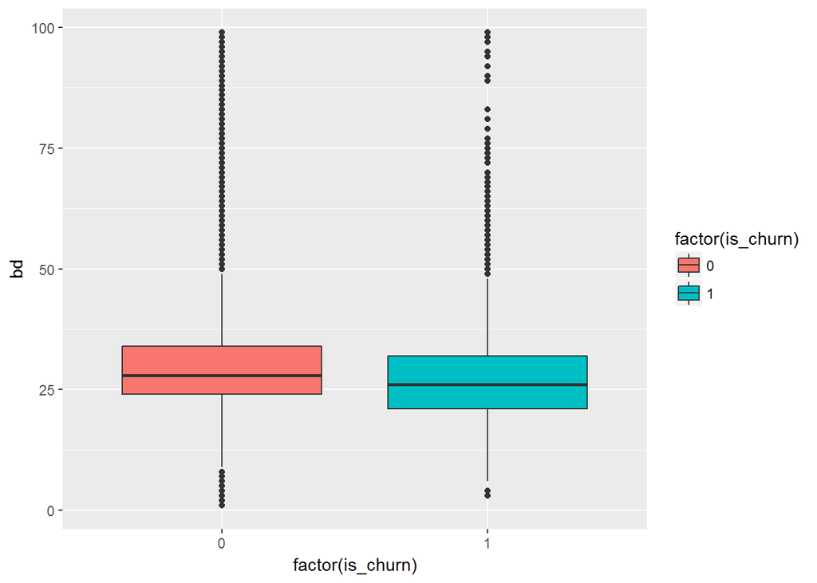

```r
ggplot(no_outliers,aes(x=factor(is_churn),y=bd, fill = factor(is_churn)))+
  geom_boxplot()
```

since the the unreasonable ages are the majority of all observations and b/c it doesn’t seem like the distribution of age is significantly difference for users who churned and didn’t, we will remove the variable ‘bd’ from our dataset

```r
train = train %>% select(-bd)
rm(no_outliers)
```

from the multiple boxplots image, ‘total_secs’ has a lot of negative values

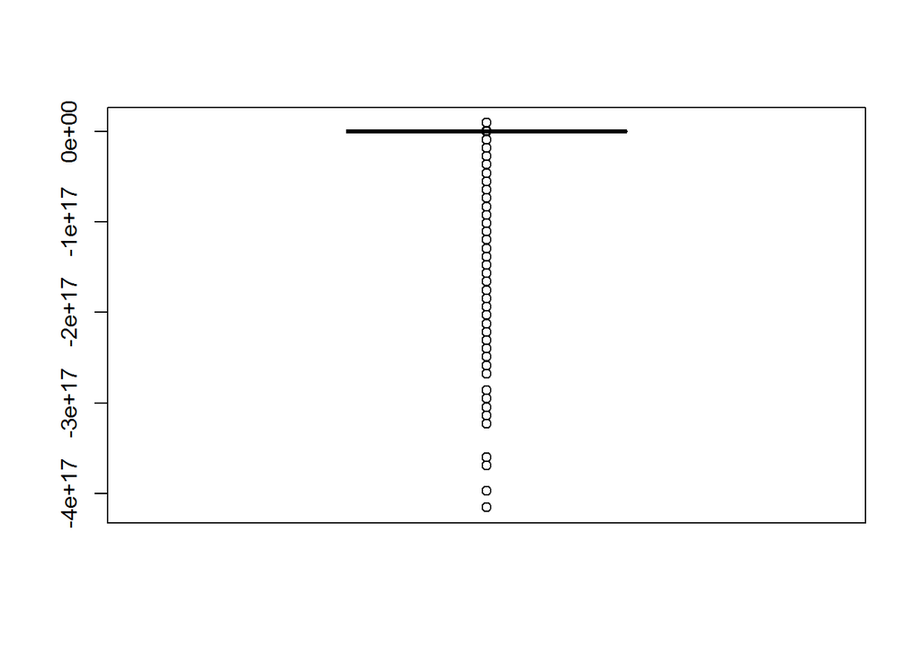

```r
boxplot(train$total_secs)
```

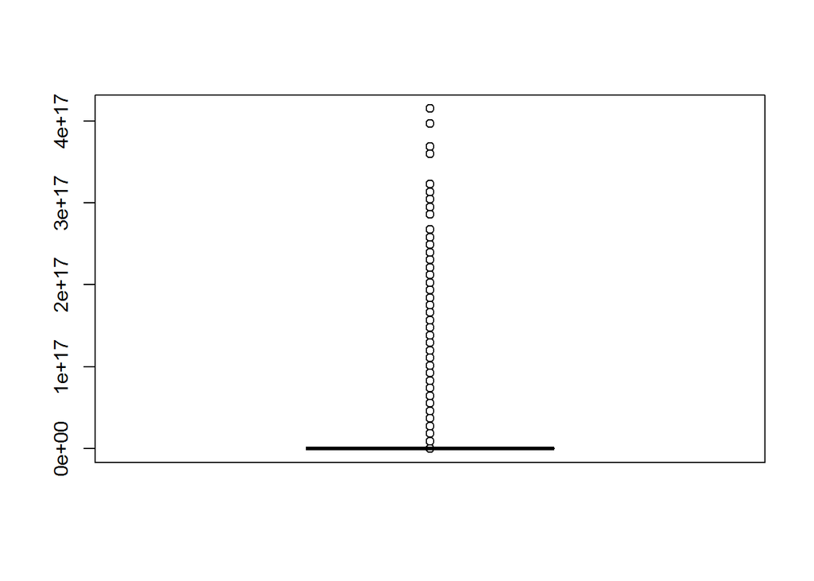

```r
boxplot(abs(train$total_secs)) #the negatives don't look like typos due to their large absolut value
```

```r
sum(train$total_secs<0)/nrow(train) #observations with negative 'total_secs' account for 1.9% of the entire 'train' dataset
```

```
## [1] 0.01884955
```

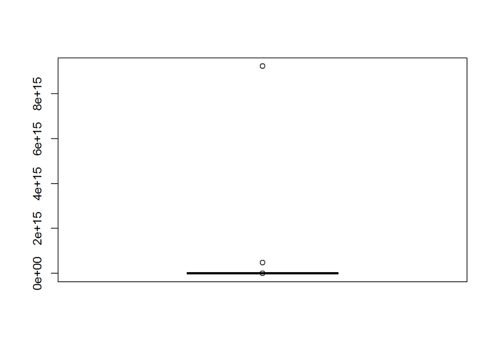

```r
#thus, we decided to remove them
train <- train[!which(train$total_secs<0),]
boxplot(train$total_secs) #potential positive outliers
```

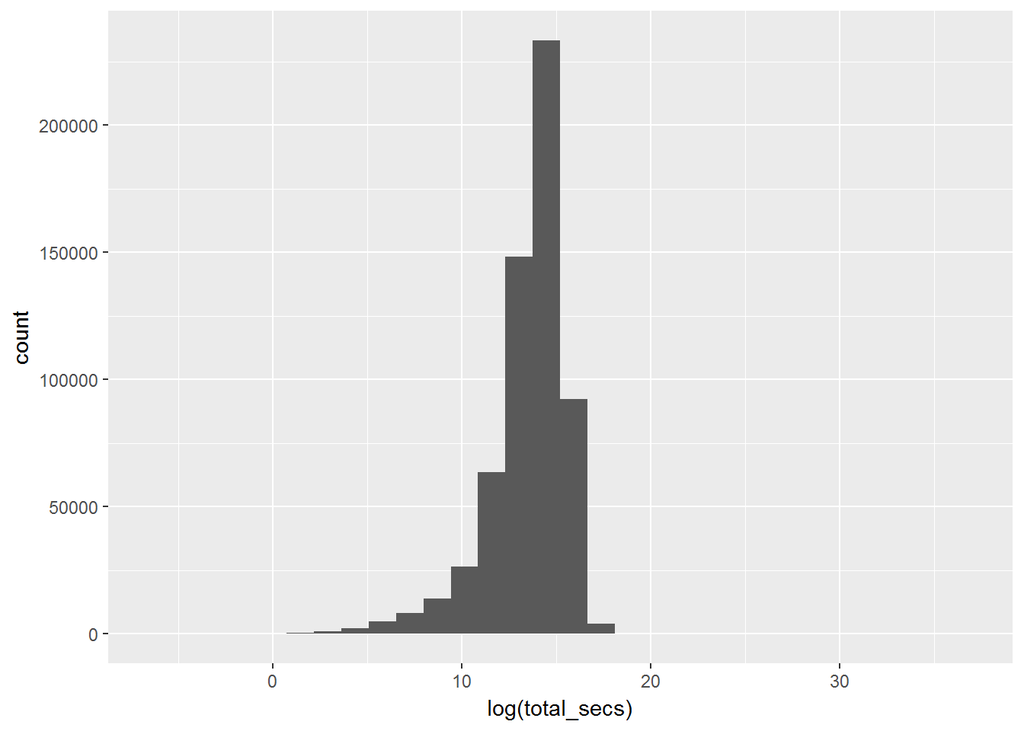

```r
ggplot(train,aes(x=log(total_secs)))+
  geom_histogram()
```

```r
train$total_secs[which(log(train$total_secs)>20)] #only 16 outliers
```

```
##  [1] 9.223372e+15 9.223372e+15 9.223372e+15 1.425677e+09 9.223372e+15
##  [6] 1.424409e+09 9.223372e+15 4.719698e+14 1.037502e+09 9.223372e+15
## [11] 9.223372e+15 9.223372e+15 9.223372e+15 9.223372e+15 9.210507e+08
## [16] 9.223372e+15
```

```r
train = train[!which(log(train$total_secs)>20),]
```

visualizing all numerics again

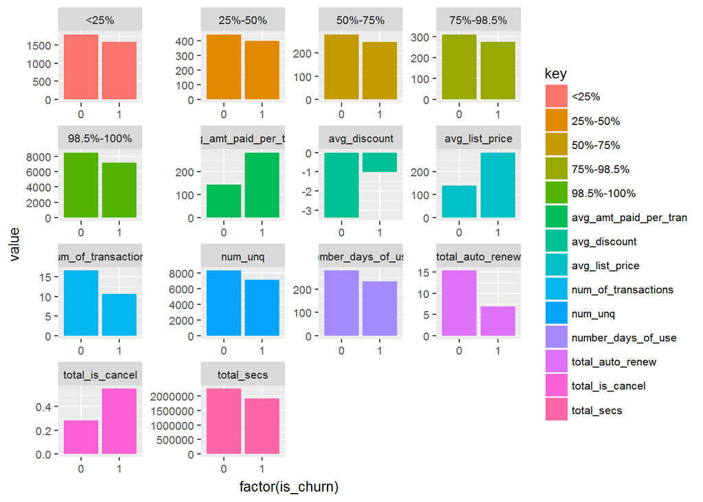

```r
train_plot2 <- Filter(is.numeric,train) %>%
  gather (key, value,-is_churn)

ggplot(train_plot2,aes(x=factor(is_churn),y=value,fill=key))+
  geom_bar(position='dodge',stat='summary',fun.y='mean')+
  facet_wrap(~ key, scales="free")+ theme(text = element_text(size=10))
```

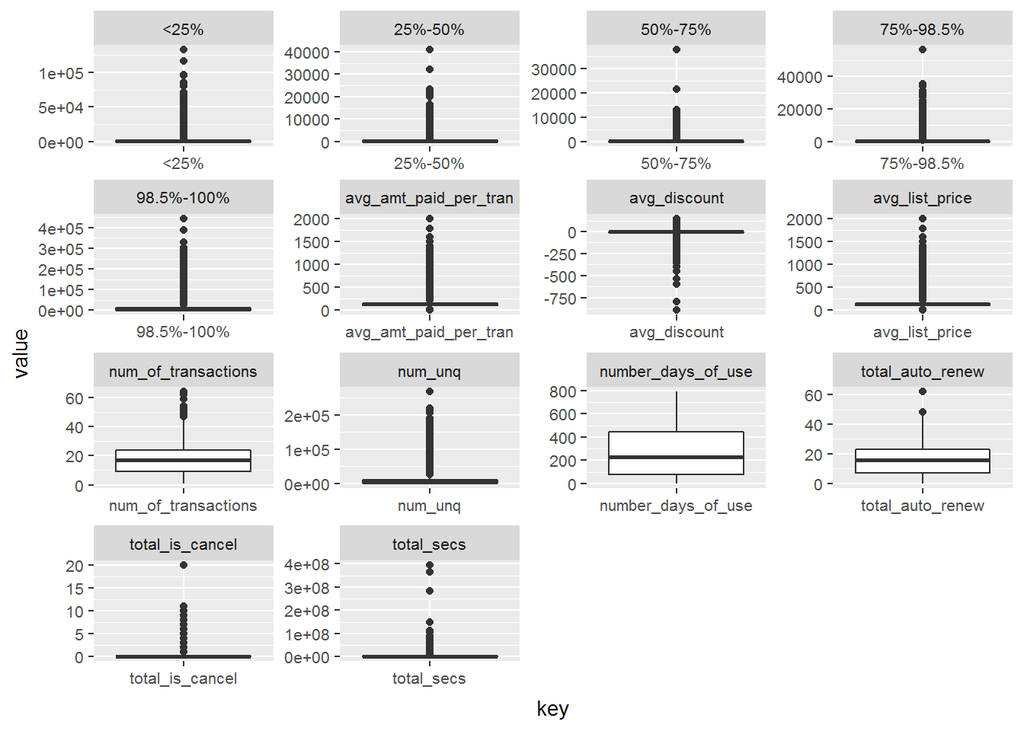

```r
ggplot(train_plot2,aes(x=key,y=value))+
  geom_boxplot()+
  facet_wrap( ~ key, scales="free")+
  theme(text = element_text(size=10))
```

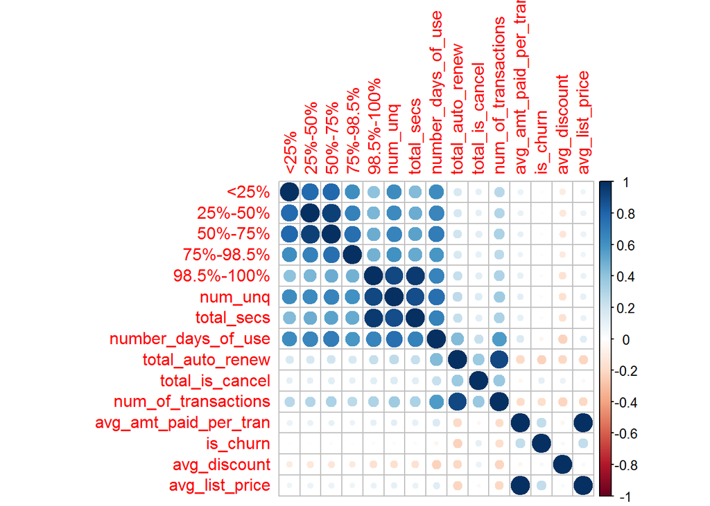

```r
#correlation
corrplot(cor(Filter(is.numeric, train)))
```

```r
#It looks like the group of continuous variables that refers to number of songs that a user play certain percentage are correlated among themselves.
```

#### Data Visualization for non-numeric variables

> number of users by gender: We checked how a user’s gender affects churn rate. It appeared that there was no difference in the churning rate between males and females, yet, the unidentified genders had lower churning rate relative to the identified ones.

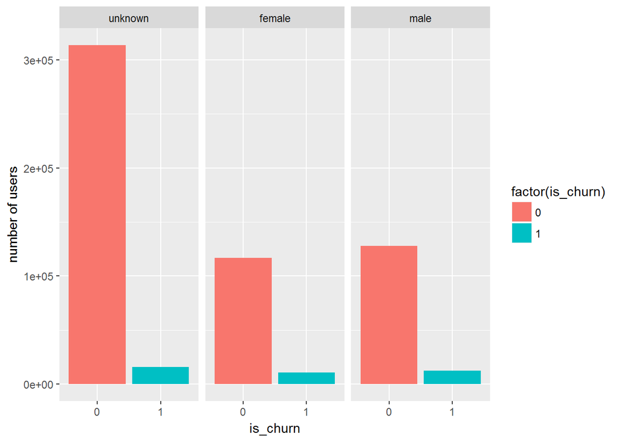

```r
ggplot(train, aes(x = factor(is_churn), fill = factor(is_churn)))+
  geom_bar(position='dodge') +
  facet_wrap(~ gender)  +labs(x="is_churn",y="number of users")
```

> sum of number of transactions by city: We used a bar plot to look at the total number of transactions performed by users from each city and then factored each city by the predictive variable. Thus, we discovered that most of our users (51.6%) came from city ‘1’. Also, cities 4, 5, 13, 15, and 22 produced significant number of users as well.

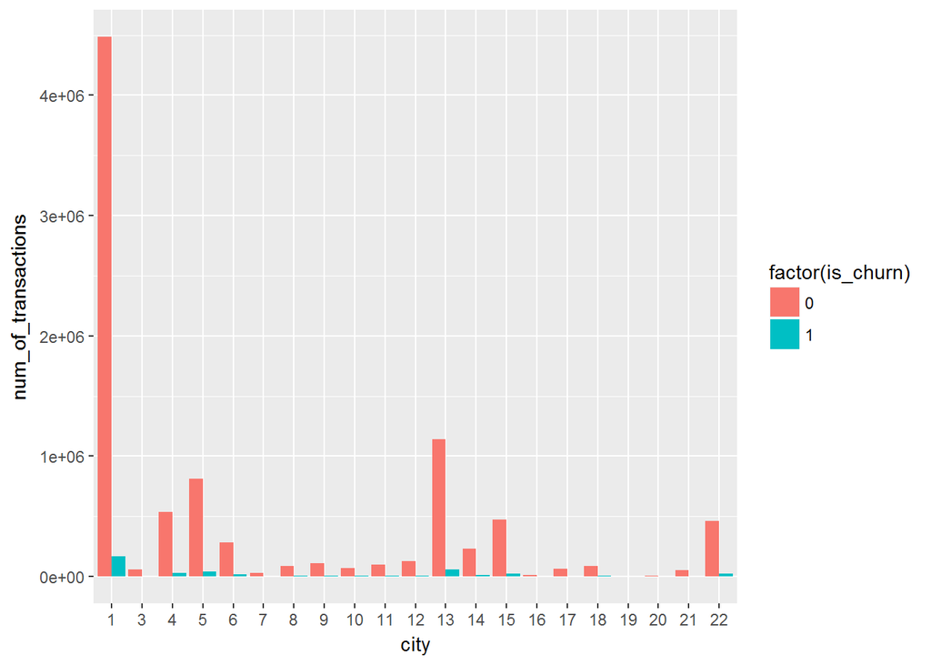

```r
ggplot(train, aes(x = city, y = num_of_transactions, fill = factor(is_churn)))+
  geom_bar(position='dodge',stat='summary',fun.y='sum')
```

> number of users in each city by gender:We looked at the number of users that came for each city in our data and segmented it by the user’s gender. It allowed us to identify that city ‘1’ was a major source for users who didn’t specify their gender relatively to all other cities in our data.

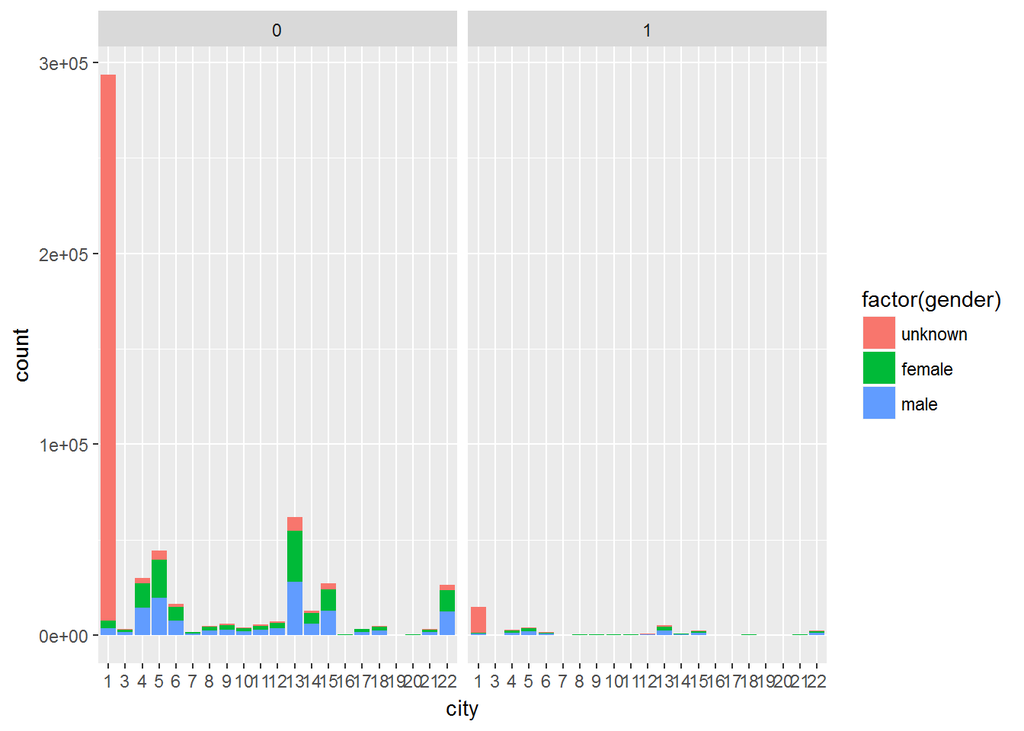

```r
ggplot(train, aes(x = city, fill = factor(gender)))+
         geom_bar(position='stack')+
          facet_wrap(~ is_churn)
```

> mean of the number of transactions by registeration channel: Lastly, we investigated the average number of transactions by the registration channel a user used to see how it influences our predictive variable. We discovered that registration methods 3, 4, and 9 had significant difference in the average number of transactions between users who churned and didn’t churn.

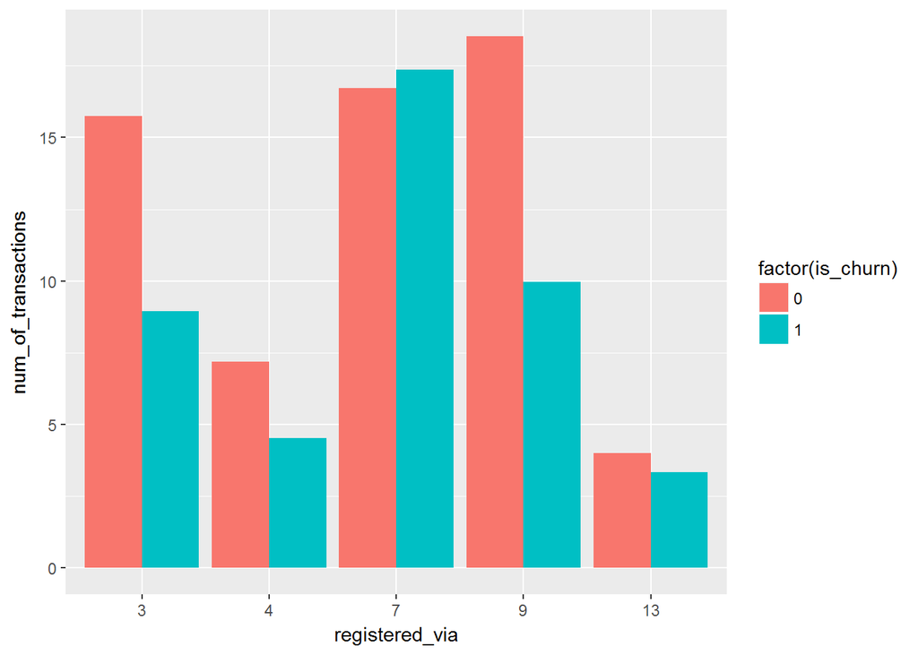

```r
ggplot(train, aes(x = registered_via, y = num_of_transactions, fill = factor(is_churn)))+
  geom_bar(position='dodge',stat='summary',fun.y='mean')
```